# Usage of Association Rules mining in Recommender Systems

### Introduction

One of the areas in which algorithmic research has created the biggest value added is **recommender systems** (RS). In an information era, amount of content available for each person is impossible to consume in a lifetime. For a site or service providing any content, there is a need to help user in finding the content he is searching for or is appropriate for him. Depending on the service type, it can help increase sales (as on e-commerce sites), make the user spend more time on the website (like in social media), or simply provide most valuable content for the user thus increasing his satisfaction (Netflix, Spotify etc.).

A breakthrough for this area of research was Netflix Prize. In 2006, this company has offered 1 million dollars for coming up with a movie recommendation engine significantly better than the on used before. This reward has motivated researchers to coming up with novel methods, some of which are being used to this day. The best solution was an ensemble of 107 techniques blended into one prediction.

### Methods

The family of recommender algorithms is wide. Main approaches include Collaborative Filtering, Content-Based Filtering, Association Rules mining and various hybrid methods obtained by ensembling couple of methods together. Last approach is aimed at reducing some disadvantages of stand-alone methods. For example, common situation occuring in real-life data is cold start problem, when there are no previous ratings of an item.

In this paper I have concentrated on two approaches, namely Collaborative Filtering and association rules mining.

#### Collaborative filtering

Collaborative filtering is a family of recommender system algorithms. It is based on obtaining similarities of entities based on previous rating/transactions data. If two users have agreed in the past, there is a big chance that they will agree in the future. This approach is in opposite to content-based filtering, in which next items are recommended based on the content (e.g. movie plot or some audio characteristics of songs).

Superiority of collaborative filtering over content-based lies mostly in the fact that analyzing content of an item requires really complex methods, if it is feasible at all. For example, it is possible to analyze image data only to some extent, and comprehension of images by humans is still superior to any algorithm.

There are two main types of CF - item-based and user-based. First one is based on finding similar items (based on previous ratings). After that, user is recommended items which are similar to the one chosen before. User-based collaborative filtering is based on finding similar users. If the history of choices are similar, there is a big chance that next purchases will be also similar.

### Data

In this paper I have tried to implement a movie recommendation engine. The MovieLens dataset is widely popular in RS development. A standard version contains information about 20 million user ratings. In this study, to reduce analysis time, I have used a smaller subset of this dataset, containing 100 000 ratings made by 600 users for 9 000 movies.

The part of the dataset I have used in this study is contained in two csv files. Main table is `ratings`, which contains information about user, movie id, rating and timestamp of rating. Timestamp is converted to human-readable value. I have also joined movie title to rating information

```r
library(recommenderlab)
library(tidyverse)
library(readr)
library(arules)
library(arulesViz)
```

```r
#' userId | movieId | rating | timestamp
ratings <- read_csv("data/ratings.csv")

#' movieId | title | genres (pipe separated)
movies <- read_csv("data/movies.csv")


ratings %>%
  rename(user_id = userId,
         movie_id = movieId) %>%
  mutate(timestamp = as.POSIXct(timestamp,
                                origin = "1970-01-01")) -> ratings

movies %>%
  rename(movie_id = movieId) -> movies

ratings %>%
  left_join(movies) %>%
  select(-genres, -movie_id) %>%
  rename(movie_id = title) -> ratings
```

### Analysis

To compare UBCF and apriori algorithms, I have created a following experimental setting. I have divided the dataset into train and test split. As the timestamp is present in the data, I have decided to employ approach similar to the one used in time-series cross-validation. The test dataset contains last 30 ratings made by each user. I have filtered out the users with less ratings made. This is also to eliminate noise in the dataset.

Although collaborative filtering can use numeric rating to improve predictions, for comparison with apriori algorithm I have decided to leave out that information.

There are various R packages for creating recommender systems. `arules` provides a set of association rules mining functions. As for RS, there is a package called `recommenderlab`. It serves as a wrapper over methods defined in `arules` and other packages. The main strength lies in its versatility and unified interface for various methods - it is possible to run complex validation of different approaches and algorithms in the same way. However, its peculiar syntax and usage of S4 object system make it unpleasant to use and incompatible with other packages.

First step is to filter out non-active users. I have also made a training-test split based on timestamp obtained for each user.

```r
# Filter out users with less than 30 ratings
ratings %>%
  group_by(user_id) %>%
  summarise(cnt_votes = n()) %>%
  filter(cnt_votes > 30) %>%
  .$user_id -> big_users

ratings_filtered <- ratings %>%
  filter(user_id %in% big_users)

# Do a Train-test split
no_obs_to_test <- 30

ratings_filtered <- ratings_filtered %>%
  mutate(id = row_number())

ratings_filtered %>%
  arrange(user_id, timestamp) %>%
  group_by(user_id) %>%
  mutate(time = row_number(), # convert timestamp to ranking
         inv_time = max(time) - time + 1) %>%
  ungroup() -> ratings_ordered

# inv_time = 1 - most recent
# time = 1 - oldest

ratings_ordered %>%
  filter(inv_time > no_obs_to_test) -> training_set

ratings_ordered %>%
  filter(inv_time <= no_obs_to_test) -> test_set
```

Training set contains 83201 observations, while test set - 14940.

```r
training_set %>%
  head(5) %>%
  knitr::kable() %>%
  kableExtra::kable_styling()
```

| user_id | rating | timestamp | movie_id | id | time | inv_time |
| --- | --- | --- | --- | --- | --- | --- |
| 1 | 4 | 2000-07-30 20:08:19 | She’s the One (1996) | 44 | 1 | 232 |
| 1 | 5 | 2000-07-30 20:08:19 | Star Wars: Episode VI - Return of the Jedi (1983) | 74 | 2 | 231 |
| 1 | 5 | 2000-07-30 20:08:43 | Bambi (1942) | 121 | 3 | 230 |
| 1 | 4 | 2000-07-30 20:08:43 | Star Wars: Episode I - The Phantom Menace (1999) | 172 | 4 | 229 |
| 1 | 4 | 2000-07-30 20:08:43 | 13th Warrior, The (1999) | 184 | 5 | 228 |

Below I have created two recommender models using `recommenderlab`. The function requires to convert the dataset to a `binaryRatingMatrix` format previously.

```r
training_set %>%
  select(user_id, movie_id) %>%
  mutate(rating = 1) %>%
  as.data.frame() -> training_ratings_matrix

training_affinity_matrix <- as(training_ratings_matrix,
                               "binaryRatingMatrix")

ubcf_model <-
  recommenderlab::Recommender(training_affinity_matrix,
                              method = "UBCF")

apriori_model <-
  recommenderlab::Recommender(training_affinity_matrix,
                              method = "AR",
                              parameter = list(supp = 0.1, conf = 0.5))
```

After obtaining models, the packages provides an interface using function `predict`. Below I have predicted 20 next films to watch by each user. One thing worth mentioning is that apriori algorithm is not always capable of producing that amount of ratings.

```r
ubcf_predictions_raw <- predict(ubcf_model, training_affinity_matrix, n = 20, type = "topN")
ubcf_predictions_raw <- as(ubcf_predictions_raw, "list")

apriori_predictions_raw <- predict(apriori_model, training_affinity_matrix, n = 20, type = "topN")
apriori_predictions_raw <- as(apriori_predictions_raw, "list")
```

Output of above code chunk is a list containing information about recommended movies for each user. For user 1, first few entries look like this:

```r
ubcf_predictions_raw[[1]][1:10]
```

```
##  [1] "Terminator, The (1984)"
##  [2] "Die Hard (1988)"
##  [3] "Terminator 2: Judgment Day (1991)"
##  [4] "Independence Day (a.k.a. ID4) (1996)"
##  [5] "Aliens (1986)"
##  [6] "Speed (1994)"
##  [7] "Groundhog Day (1993)"
##  [8] "Hunt for Red October, The (1990)"
##  [9] "Godfather, The (1972)"
## [10] "Sixth Sense, The (1999)"
```

To compare recommended movies and actually seen ones, some amount of data wrangling is needed. Below I have computed actual statistics concerning both sets.

```r
# Function to compute accuracy measures needed
accuracy_measures <- function(predicted, actual) {
  tibble(
    in_both = sum(predicted %in% actual),
    only_in_predicted = length(predicted) - in_both,
    only_in_actual = length(actual) - in_both,
    predicted_cnt = length(predicted),
    actual_cnt = length(actual)
  )
}

# Reduce test set to a list with set of movies for each user
test_set %>%
  select(user_id, movie_id) %>%
  group_by(user_id) %>%
  nest() %>%
  .$data %>%
  as.list() %>%
  map(function(x)
    as.character(x$movie_id)) -> set

# Apriori
map2(apriori_predictions_raw,
     set,
     function(x, y)
       list(predicted = x, actual = y)) -> comparison

comparison %>%
  map_df(function(x)
    accuracy_measures(x$predicted,
                      x$actual)) %>%
  mutate(user_id = row_number()) -> apriori_measures_raw

# UBCF
map2(ubcf_predictions_raw,
     set,
     function(x, y)
       list(predicted = x, actual = y)) -> comparison


comparison %>%
  map_df(function(x)
    accuracy_measures(x$predicted,
                      x$actual)) %>%
  mutate(user_id = row_number()) -> ubcf_measures_raw


# Calculate measures for apriori
apriori_measures_raw %>%
  rename(true_positive = in_both,
         false_positive = only_in_predicted) %>%
  mutate(precision = true_positive / predicted_cnt) %>%
  select(user_id, precision, everything()) -> apriori_measures

# apriori_measures[is.na(apriori_measures)] <- 0

# Calculate measures for UBCF
ubcf_measures_raw %>%
  rename(true_positive = in_both,
         false_positive = only_in_predicted) %>%
  mutate(precision = true_positive / predicted_cnt) %>%
  select(user_id, precision, everything()) -> ubcf_measures
```

This is how measures table looks like:

##### apriori

```r
apriori_measures %>%
  head(5) %>%
  knitr::kable() %>%
  kableExtra::kable_styling()
```

| user_id | precision | true_positive | false_positive | only_in_actual | predicted_cnt | actual_cnt |
| --- | --- | --- | --- | --- | --- | --- |
| 1 | 0.15 | 3 | 17 | 27 | 20 | 30 |
| 2 | NaN | 0 | 0 | 30 | 0 | 30 |
| 3 | 0.05 | 1 | 19 | 29 | 20 | 30 |
| 4 | 0.15 | 3 | 17 | 27 | 20 | 30 |
| 5 | 0.00 | 0 | 20 | 30 | 20 | 30 |

`NA` values in precision occur when for particular user there are no recommendations made.

##### UBCF

```r
ubcf_measures %>%
  head(5) %>%
  knitr::kable() %>%
  kableExtra::kable_styling()
```

| user_id | precision | true_positive | false_positive | only_in_actual | predicted_cnt | actual_cnt |
| --- | --- | --- | --- | --- | --- | --- |
| 1 | 0.30 | 6 | 14 | 24 | 20 | 30 |
| 2 | 0.00 | 0 | 20 | 30 | 20 | 30 |
| 3 | 0.05 | 1 | 19 | 29 | 20 | 30 |
| 4 | 0.20 | 4 | 16 | 26 | 20 | 30 |
| 5 | 0.05 | 1 | 19 | 29 | 20 | 30 |

To compare recommender systems based on binary data (as opposed to predicting rating for specific item), one can use the same measures as in classfication setting. That is, true positive occurs when system recommended the same movie as there exists in test set (for specific user). However, for most of the algorithms a concept of negatives does not make sense - recommendation systems show what are the items that the user would be interested in, not the ones that should not be recommended. As such, a reasonable measure for comparing the models is precision. This is a proportion of true positives to the number number of recommendations produced.

As I have created recommendations for each user separately, it is possible to calculate both general precision and an estimate for each user. The first measure is 0.149 and 0.090 for User-Based Collaborative Filtering and Apriori, respectively.

One way to compare user-wise score is by looking at the distributions. Below I have included both density plot and summary table for both systems. As can be seen, the distribution for UBCF is slightly more oriented to the right, that is, more correct recommendations are made.

##### Density plot

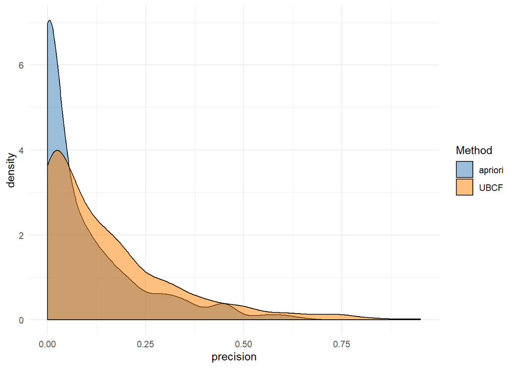

```r
bind_rows(apriori_measures,
          ubcf_measures,
          .id = c("Method")) %>%
  mutate(Method = ifelse(Method == 1, "apriori", "UBCF")) %>%
  ggplot(aes(x = precision, fill = Method)) +
  geom_density(alpha = 0.5) +
  scale_fill_manual(values = RColorBrewer::brewer.pal(8, "Set1")[c(2, 5)]) +
  # facet_grid(rows = vars(method)) +
  theme_minimal()
```

##### Summary table

```r
bind_rows(apriori_measures,
          ubcf_measures,
          .id = c("Method")) %>%
  mutate(Method = ifelse(Method == 1, "apriori", "UBCF")) %>%
  filter(!is.na(precision)) %>%
  select(Method, precision) %>%
  group_by(Method) %>%
  summarise(
    `Min` = min(precision),
    `25%` = quantile(precision, 0.25),
    `Median` = quantile(precision, 0.5),
    `Mean` = mean(precision),
    `75%` = quantile(precision, 0.75),
    `Max` = max(precision)
  ) %>%
  mutate_if(is.numeric, round, 2) %>%
  knitr::kable() %>%
  kableExtra::kable_styling()
```

| Method | Min | 25% | Median | Mean | 75% | Max |
| --- | --- | --- | --- | --- | --- | --- |
| apriori | 0 | 0 | 0.05 | 0.09 | 0.15 | 0.65 |
| UBCF | 0 | 0 | 0.10 | 0.15 | 0.20 | 0.95 |

### Summary

In this paper I have presented two possible approaches to Recommendation task- namely apriori and User-Based Collaborative Filtering algoritms. UBCF showed to be superior over association rules analysis. This is consistent with current trend in recommendation systems development - collaborative filtering is currently more popular one.